# Group Portion: Galton Data

STT2860 F22 Project 03

Caleb, Micah, Graham, Summer

Monday, December 12, 2022 @ 09:48 PM

## Setup

### Packages Used

```r
library(tidyverse)
```

### Datasets Used

#### Background of the Data

Francis Galton, a cousin of Charles Darwin, studied the relationship between parent heights and the heights of their offspring. His pioneering [1886 article](https://galton.org/essays/1880-1889/galton-1886-jaigi-regression-stature.pdf) is the first appearance of regression analysis in print. He originated many statistical terms and concepts, including regression, correlation, deviate, quartile, and percentile, as well as median for the midpoint of a distribution. The `galtondata` dataset was [recreated under the direction of Dr. James A. Hanley](http://www.medicine.mcgill.ca/epidemiology/hanley/galton/) using Galton’s [original paper notebooks](http://www.medicine.mcgill.ca/epidemiology/hanley/galton/notebook/index.html) containing the measurement data.

#### Variables

- `FamilyID`: family identifier, labeled 1 to 205
- `Children` : number of children in the family
- `Father`: father’s measured height in inches
- `Mother`: mother’s measured height in inches
- `Child`: whether the child was a son or a daughter
- `Height`: child’s measured height in inches

```r
galtondata <- readRDS("~/Git_Repositories/Project 3/data/galtondata.rds")
glimpse(galtondata)
```

```
Rows: 934
Columns: 6
$ FamilyID <dbl> 1, 1, 1, 1, 2, 2, 2, 2, 3, 3, 4, 4, 4, 4, 4, 5, 5, 5, 5, 5, 5…
$ Children <dbl> 4, 4, 4, 4, 4, 4, 4, 4, 2, 2, 5, 5, 5, 5, 5, 6, 6, 6, 6, 6, 6…
$ Father   <dbl> 78.5, 78.5, 78.5, 78.5, 75.5, 75.5, 75.5, 75.5, 75.0, 75.0, 7…
$ Mother   <dbl> 67.0, 67.0, 67.0, 67.0, 66.5, 66.5, 66.5, 66.5, 64.0, 64.0, 6…
$ Child    <chr> "Son", "Daughter", "Daughter", "Daughter", "Son", "Son", "Dau…
$ Height   <dbl> 73.2, 69.2, 69.0, 69.0, 73.5, 72.5, 65.5, 65.5, 71.0, 68.0, 7…
```

## Analyses

### Create the Analysis Datasets

#### Children Dataset

In his [original article](http://www.stat.ucla.edu/~nchristo/statistics100C/history_regression.pdf) on regression, Galton explained: “My data consisted of the heights of 930 adult children and of their respective parentages, 205 in number. In every case I transmuted the female statures to their corresponding male equivalents and used them in their transmuted form… The factor I used was 1.08, which is equivalent to adding a little less than one-twelfth to each female height. It differs a very little from the factors employed by other anthropologists…”

Manipulate the dataset so that it has the following structure.

- contains these variables:
  - `familyid` = ID number of the family
  - `num_children`= number of children in the family
  - `father_ht` = father’s measured height
  - `mother_ht` = mother’s “transmuted” height (per Galton)
  - `midparent_ht` = average of the parents’ heights (using transmuted mother)
  - `child_sex`= whether the child is a son/daughter, in lower case (i.e., `son` vs. `Son`)
  - `child_ht_raw` = child’s measured height in inches
  - `child_ht` = child’s height with daughters “transmuted” (per Galton)
- is arranged according to:
  - ascending order of familyid
  - sons before daughters within each family
  - ascending order of measured height within each sex of child

```r
galtondataA <- galtondata %>%
  mutate(mother_ht = 1.08 * Mother,
         child_ht = if_else(Child == "Daughter", 1.08 * Height, Height),
         midparent_ht = (Father + mother_ht) / 2,
         child_sex = tolower(Child))


galtondataC <- galtondataA %>%
  select(familyid = FamilyID,
         num_children = Children,
         father_ht = Father,
         mother_ht,
         midparent_ht,
         child_sex,
         child_ht_raw = Height,
         child_ht) %>%
arrange(familyid, desc(child_sex), child_ht_raw)

glimpse(galtondataC)
```

```
Rows: 934
Columns: 8
$ familyid     <dbl> 1, 1, 1, 1, 2, 2, 2, 2, 3, 3, 4, 4, 4, 4, 4, 5, 5, 5, 5, …
$ num_children <dbl> 4, 4, 4, 4, 4, 4, 4, 4, 2, 2, 5, 5, 5, 5, 5, 6, 6, 6, 6, …
$ father_ht    <dbl> 78.5, 78.5, 78.5, 78.5, 75.5, 75.5, 75.5, 75.5, 75.0, 75.…
$ mother_ht    <dbl> 72.36, 72.36, 72.36, 72.36, 71.82, 71.82, 71.82, 71.82, 6…
$ midparent_ht <dbl> 75.43, 75.43, 75.43, 75.43, 73.66, 73.66, 73.66, 73.66, 7…
$ child_sex    <chr> "son", "daughter", "daughter", "daughter", "son", "son", …
$ child_ht_raw <dbl> 73.2, 69.0, 69.0, 69.2, 72.5, 73.5, 65.5, 65.5, 71.0, 68.…
$ child_ht     <dbl> 73.200, 74.520, 74.520, 74.736, 72.500, 73.500, 70.740, 7…
```

#### Parents Dataset

From the child dataset, select the variables `familyid`, `num_children`, `father_ht`, and `mother_ht`. Use `distinct()` to reduce the dataset so it contains only one unique row per family. (Hint: The final dataset should have 205 rows/observations and four variables/columns.)

```r
galtondataD <- galtondataC %>% select(familyid, num_children, father_ht, mother_ht) %>%
     distinct(familyid, num_children, father_ht, mother_ht)
glimpse(galtondataD)
```

```
Rows: 205
Columns: 4
$ familyid     <dbl> 1, 2, 3, 4, 5, 6, 7, 8, 9, 10, 11, 12, 13, 14, 15, 16, 17…
$ num_children <dbl> 4, 4, 2, 5, 6, 1, 6, 3, 1, 1, 8, 1, 2, 2, 3, 9, 6, 3, 1, …
$ father_ht    <dbl> 78.5, 75.5, 75.0, 75.0, 75.0, 74.0, 74.0, 74.0, 74.5, 74.…
$ mother_ht    <dbl> 72.36, 71.82, 69.12, 69.12, 63.18, 73.44, 73.44, 71.82, 7…
```

### Visualization 1: Updated Scatterplot

#### Galton’s Visualization

In his original paper (linked above), Galton created several tables and diagrams. His “Diagram Based on Table 1” of them is similar in concept to a scatterplot. Rather than dots, he grouped/tabulated the data, and then used the count of how many people were grouped at the coordinate pairs in his grid, with child as the x-axis and mid-parent as the y-axis. There are two scales: inches and deviations from 68.25 inches.

#### Your Data Visualization

**This plot uses the children dataset.**

Create a scatterplot of child height (x-axis) versus mid-parent height (y-axis). Ordinarily, we might reverse the axes here because analysts would be more likely to model child height as a function of parent height, but we want to be able to compare the updated plot to Galton’s original.

Include the following.

- make your dots larger than the default size to help show density
- set transparency to adjust for overplotting and help show density
- use `color =` in the `aes` to differentiate sons versus daughters
- use `scale_color_manual()` to choose two colorblind-safe colors
- scale both axes so that there is a tick mark at every whole inch
- use `coord_fixed()` so that the axes have the same unit spacing
- add better x- and y-axis labels, including the units of measure
- add an informative title (you may optionally include a subtitle)
- add `color =` to `labs()` to set the legend title to `"gender of child"`
- use a built-in theme (e.g., `theme_linedraw()`) to add formatting
- use `theme()` to move the legend to the bottom of the scatterplot

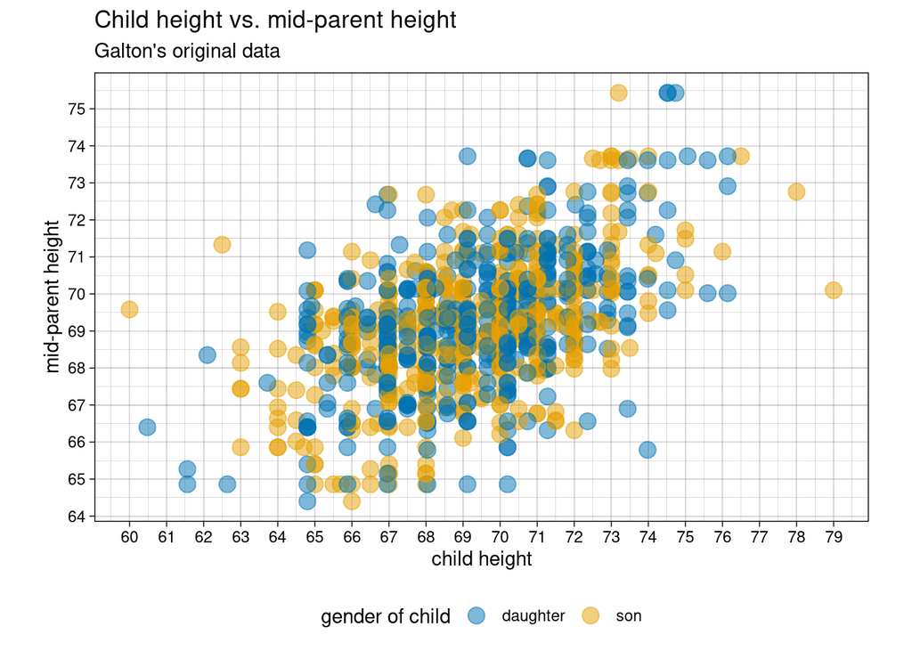

```r
ggplot(galtondataC, aes(x = child_ht, y = midparent_ht, color = child_sex)) +
  geom_point(size = 4, alpha = 0.5) +
  scale_color_manual(values = c("#0072B2", "#E69F00")) +
  scale_x_continuous(breaks = seq(40, 80, by = 1)) +
  scale_y_continuous(breaks = seq(40, 80, by = 1)) +
  coord_fixed() +
  labs(x = "child height",
       y = "mid-parent height",
       color = "gender of child",
       title = "Child height vs. mid-parent height",
       subtitle = "Galton's original data") +
  theme_linedraw() +
  theme(legend.position = "bottom")
```

### Visualization 2: “Transmuting” Effect

**These plots use the children dataset.**

#### The Raw Data

Use `histogram()` or `density()` to plot `child_ht_raw`. Use faceting so that there is a separate plot for sons and daughters, with one plot above the other (*not* side by side). If you use a histogram, change the default `bins = 30` to a reasonable value for the data. Choose appropriate colors, labels, themes, and/or and other types of formatting that you feel will enhance the meaning or visual appearance of the plot.

```r
library(ggplot2)
glimpse(galtondataC)
```

```
Rows: 934
Columns: 8
$ familyid     <dbl> 1, 1, 1, 1, 2, 2, 2, 2, 3, 3, 4, 4, 4, 4, 4, 5, 5, 5, 5, …
$ num_children <dbl> 4, 4, 4, 4, 4, 4, 4, 4, 2, 2, 5, 5, 5, 5, 5, 6, 6, 6, 6, …
$ father_ht    <dbl> 78.5, 78.5, 78.5, 78.5, 75.5, 75.5, 75.5, 75.5, 75.0, 75.…
$ mother_ht    <dbl> 72.36, 72.36, 72.36, 72.36, 71.82, 71.82, 71.82, 71.82, 6…
$ midparent_ht <dbl> 75.43, 75.43, 75.43, 75.43, 73.66, 73.66, 73.66, 73.66, 7…
$ child_sex    <chr> "son", "daughter", "daughter", "daughter", "son", "son", …
$ child_ht_raw <dbl> 73.2, 69.0, 69.0, 69.2, 72.5, 73.5, 65.5, 65.5, 71.0, 68.…
$ child_ht     <dbl> 73.200, 74.520, 74.520, 74.736, 72.500, 73.500, 70.740, 7…
```

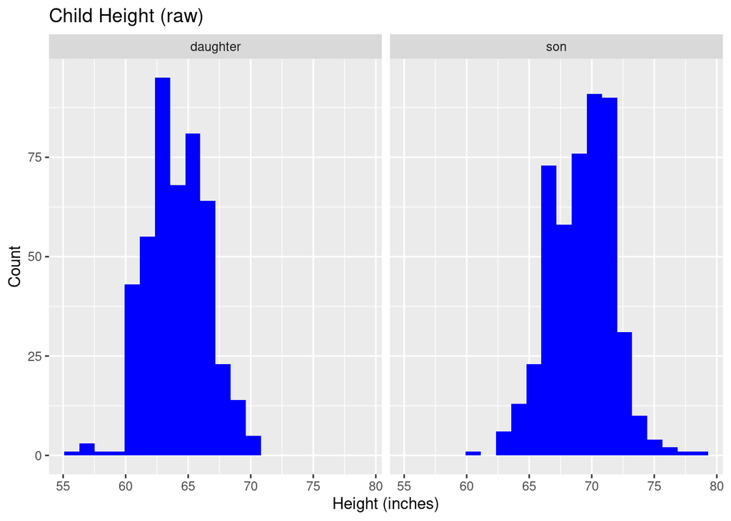

```r
ggplot(galtondataC, aes(x = child_ht_raw)) +
  geom_histogram(bins = 20, fill = "blue") +
  facet_wrap(~ child_sex) +
  labs(title = "Child Height (raw)",
       x = "Height (inches)",
       y = "Count")
```

Use `group_by()` and `summarize()` to calculate the mean, standard deviation, minimum, median, and maximum of the measured heights for sons and daughters.

```r
library(dplyr)
by_child_sex <- group_by(galtondataC, child_sex)
heights_summary <- summarize(by_child_sex,
                             mean = mean(child_ht_raw),
                             sd = sd(child_ht_raw),
                             min = min(child_ht_raw),
                             median = median(child_ht_raw),
                             max = max(child_ht_raw))
print(heights_summary)
```

```
# A tibble: 2 × 6
  child_sex  mean    sd   min median   max
  <chr>     <dbl> <dbl> <dbl>  <dbl> <dbl>
1 daughter   64.1  2.35    56   64    70.5
2 son        69.2  2.62    60   69.2  79
```

#### The Transmuted Data

Create a similar plot as above, this time for `child_ht`. Be sure that the labels you use clearly distinguish between this plot and the previous one, especially if the other styling is very similar.

[figure not shown]

```r
hist(galtondataC$child_ht, col = "lightblue", breaks = 20, xlim = c(60, 80),
     main = "Histogram of Child Height", xlab = "Child Height (cm)")
```

Use `group_by()` and `summarize()` to calculate the mean, standard deviation, minimum, median, and maximum of the transmuted heights for sons and daughters.

```r
summary_statistics <- galtondataC %>%
  group_by(child_sex) %>%
  summarize(mean = mean(child_ht),
            sd = sd(child_ht),
            min = min(child_ht),
            median = median(child_ht),
            max = max(child_ht))
print(summary_statistics)
```

```
# A tibble: 2 × 6
  child_sex  mean    sd   min median   max
  <chr>     <dbl> <dbl> <dbl>  <dbl> <dbl>
1 daughter   69.2  2.54  60.5   69.1  76.1
2 son        69.2  2.62  60     69.2  79
```

### Visualization 3: Number of Children

**This plot uses the parents dataset.**

Create a barplot to show the distribution of the number of children per family. Set the bars to something other than the default `width`. Scale the x-axis so that there is a tick mark for each bar. Choose appropriate colors, labels, themes, and/or and other types of formatting that you feel will enhance the meaning or visual appearance of the plot. (Hint: Use `count()` to find out how many families have a given number of children, then use that smaller summary dataset to create your plot.)

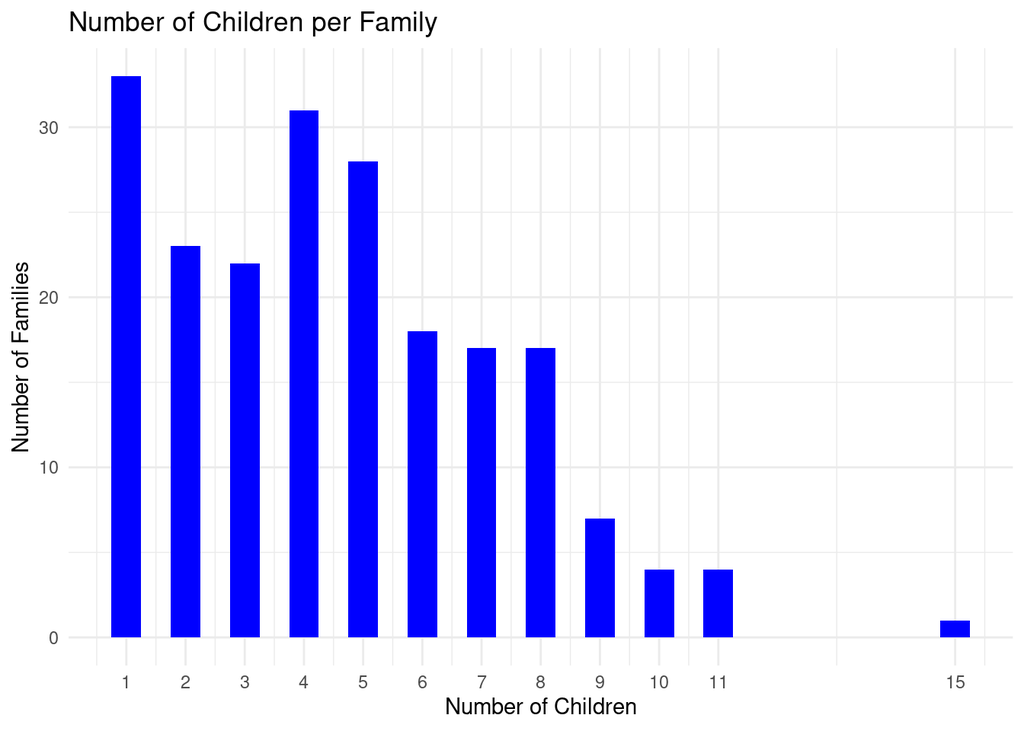

```r
num_children_counts <- count(galtondataD, num_children)
ggplot(num_children_counts, aes(x=num_children, y=n)) +
  geom_bar(stat="identity", width=0.5, fill="blue") +
  scale_x_continuous(breaks=num_children_counts$num_children) +
  xlab("Number of Children") +
  ylab("Number of Families") +
  ggtitle("Number of Children per Family") +
  theme_minimal()
```

## Questions

**Question 1:** Do you think your scatterplot is an improvement over Galton’s original diagram? Are there any other modifications and/or additions you would make to enhance the clarity or usefulness of your plot?

We believe ours is more colorful and easier to read and comprehend what is being presented.

**Question 2:** Did Galton’s “transmuting” of daughters’ heights succeed in making their data more similar to sons? How can you tell, based on your data visualizations and summaries?

**ANSWER**

It seems as if it did succeed because our plots and other data visualizations have very close similarities.

**Question 3:** Explain the rationale behind the choices you made when creating your plots, such as size, color, transparency, or other features that were not explicitly stated. What motivated your decisions?

**ANSWER**

The reason we chose these colors and styles is because they seemed to have the most appealing look for design and comprehension.

**Question 4:** Considering best practices, how does using `coord_fixed()` enhance the authenticity of the information shown in the scatterplot, such as the relationship and spread of the data?

**ANSWER**

It was a great way to spread out the axes’ and evenly distribute the data.